# Introduction to LifeIneq

2023-06-05

## Introduction

How unequally distributed are the ages at death within a population? There are many indices around to answer this question, all generally going under the umbrella terms *lifespan inequality*, *lifespan variation*, *age-at-death variation*, *compression of mortality*, or *rectangularization of the survival curve*.

For a good overview of the mathematical properties of the indices, as well as comparisons of how they perform when applied to empirical data, we suggest consulting the following (Wilmoth and Horiuchi 1999; Shkolnikov, Andreev, and Begun 2003; van Raalte and Caswell 2013; Wrycza, Missov, and Baudisch 2015).

## Background

### Choosing a measure of lifespan inequality

Variation is a broad concept. Since it is often used to make judgements on the inequality of a distribution, different indices have been developed which differ in their mathematical properties and sensitivities to different parts of the distribution. As Paul Allison (1978) (p. 865) noted,*“The choice of an inequality measure is properly regarded as a choice among alternative definitions of inequality rather than a choice among alternative ways of measuring a single theoretical construct.”* Here we outline some of the more important considerations.

### Absolute versus relative inequality

Absolute measures are generally measured in years, making them easier to interpret, but relative measures have their own advantages. Relative measures are preferred by biologists to compare species with very different life histories and life expectancies (Eakin and Witten 1995; Baudisch 2011; Colchero et al. 2016). This is less of an issue in comparing contemporary human populations, either across or within countries. In the end, we feel that the choice between measuring absolute versus relative inequality is a normative one. If there is no inherent reason for preferring absolute or relative inequality, it is good practice to present both.

### Attainment versus shortfall distribution

Relative measures of lifespan inequality have an additional specification: whether the inequality is relative to an average achieved age at death (e.g. from an attainment distribution) or to a remaining life expectancy (e.g. from a shortfall distribution). When following a cohort from birth, the means of the two distributions are the same—average age at death equals remaining life expectancy at birth.

Often though, we want to measure the lifespan inequality of populations or groups based on a conditional age-at-death distribution—in other words, a distribution with a starting age greater than zero, where the lifespan inequality is calculated conditional on surviving to that starting age. As an example, lifespan inequality by level of completed education can only be defined from early adulthood.

In such cases, should inequality be made relative to the average age at death, conditional upon survival to age $x$, or to the average remaining life expectancy at age $x$? So far, few researchers have paid attention to this difference. There are plenty of studies based on conditional distributions, including our own, but no reflection on how the choice of denominator (the distribution type) could impact the result.

Indeed, a quick survey of the literature to date hints that the choice of conditional distribution type seems to mostly depend on the measure used rather than any theoretical justification. The coefficient of variation, the Theil Index, and the Mean Log Deviation are generally calculated from the achieved age at death distribution (Hakkert 1987; van Raalte et al. 2012; Permanyer and Scholl 2019, 2019; Shkolnikov and Andreev 2010; Németh 2017; Seaman et al. 2020). The Keyfitz-Leser life table entropy measure is instead calculated from shortfall distributions (Bramajo, Permanyer, and Blanes 2022). The Gini coefficient, when calculated from the Kendall and Stuart definition, has used attained ages (Permanyer and Scholl 2019), while when calculated based on the Hanada formulation has used remaining life expectancy (Shkolnikov, Andreev, and Begun 2003).

Is there any reason to prefer one concept over the other? We ourselves cannot decide, and prefer to leave this debate to play out in the literature. All of the relative measures of lifespan variation included in the LifeIneq package can be calculated in both ways, and we have added an argument to relative measures to make this choice explicit. In one of the empirical examples of this vignette, we demonstrate how important this distinction is.

## Built-in indices of variation

Currently, the `LifeIneq` package contains the following indices of lifespan inequality (listed alphabetically):

- `aid` the Absolute Inter-individual Difference, also known as the absolute Gini Coefficient
- `cov` the Coefficient of Variation of survival or remaining life
- `cp` Kannisto’s *C* measures—the shortest distance between two ages containing $p$ percent of the life table cohort’s deaths.
- `edag` the life disparity $e^{\dagger}$ measure, also called the average life years lost due to death
- `eta_dag` the mean age at death lost at death $\eta^{\dagger}$ (newly derived for this package–equivalent to `edag` but calculated by weighting the distribution of ages at death instead of remaining life by the death density)
- `drewnowski` the Drewnowski index, which is the complement of the Gini coefficient
- `gini` the Gini coefficient of survival or remaining life
- `H` the Leser-Keyfitz life table index, also called the life table entropy, which is more properly described as the elasticity of life expectancy to proportional change in mortality. It is also the relative inequality index of $e^{\dagger}$ Goldman and Lord (1986).
- `iqr` the interquartile range of the age-at-death distribution, e.g. the difference between the 75th and 25th percentile of survival ages in the life table cohort
- `mad` the mean absolute deviation in lifetable ages at death. This may be with respect to either the mean or median age at death
- `mld` the mean log deviation of survival or remaining life
- `quantile` and `quantile_lower` are quantiles of survivorship (the former is a vector made conditional upon survival to each age, the latter is a scalar). These are not inequality measures by themselves, generally, but are included for users to design own quantile-based measures beyond the `iqr` and `cp` measures.
- `sd` the standard deviation in ages at death
- `theil` the Theil index of survival or remaining life
- `var` the variance in ages at death

`Table 1` shows the formula we implemented to calculate the measure from starting age $a$.

We have dropped the ‘n’ subscript typically used to denote the width of the age interval since we prefer to calculate indices from single-year of age life tables. However all formulas could be calculated using age-intervals $[x,x+n)$ with some loss of accuracy.

The notation is as follows.

- $x$ is age
- $m_x$ is the death rate in the interval $[x,x+1)$
- $q_x$ is the probability of dying in the interval $[x,x+1)$
- $a_x$ is the number of person-years lived in the interval $[x,x+1)$
- $\ell_x$ is the number of survivors at exact age $x$
- $d_x$ is the number of deaths in the interval $[x,x+1)$
- $L_x$ is the number of person-years in the interval $[x,x+1)$
- $T_x$ is the number of person-years above age $x$
- $e_x$ is the remaining life expectancy above age $x$
- $\eta_x$ is the average age at death, conditional on survival to age $x$ (equivalent to $e_x$ + $x$)
- $\alpha_x$ is the average age at death in the interval $[x,x+1)$ (equivalent to $a_x$ + $x$)
- $q_1$ and $q_3$ are the first and third quantiles of survivorship, defaulting to the age achieved by the 25th and 75th percentiles of survivors.

In order to calculate some indices of lifespan inequality, two columns were added to a standard life table: $\alpha_{x}$ and $\eta_{x}$ defined above. Two indices, the `iqr` and the `cp` measures, use spline interpolation of the survival curve to estimate the age (to several decimals) at which a given percentile or `quantile` of the life table cohort survive to.

The formulas are given in the discrete form which are easier to work with from life tables. Since mortality is a continuous process, different assumptions made on how to discretize survival have resulted in several different formulations, not all of which are completely equivalent (although they are close).

The column `Type` refers to whether the index measures absolute or relative inequality in ages at death. For relative indices, we indicate in brackets after the index name whether the index was calculated from an achieved (achieved age at death) or shortfall (remaining life expectancy) distribution.

Table 1: LifeIneq Formulas

[output not shown]

<sup>1</sup> the `mad` can also be calculated by using the distance to the median - see help file

## Installing and loading the package

When using the package for the first time, you need to install the package from CRAN.

```r
install.packages("LifeIneq")
```

On subsequent uses, you can start from here, where we first load the package into our workspace.

```r
library(LifeIneq)
```

We recommend to use data in a single-age format, although the package can handle abridged-data formats as well. We also recommend closing out a life table at an age with few deaths. Lifespan variation is far more sensitive to mortality at higher ages than life expectancy (van Raalte and Caswell 2013), and assumptions on the mortality hazard in the open-ended age interval can make a considerable difference when this age is close to the modal age at death.

If your data have a lower than desired upper age bound, consider extrapolation methods, for instance a parametric Kannisto model (implemented in `MortalityLaws::MortalityLaw`). If your data are abridged, consider first smoothing over age, and calculating a life table by single year of age (for instance by smoothing with a pclm model in the package `ungroup` (Pascariu 2019) or with a penalized B-spline approach in the package `MortalitySmooth` (Camarda 2012)).

### Minor issues to be aware of

Some of the indices will return NaNs at the very oldest ages, beyond around the last one-tenth of a percent of deaths. This is usually owing to the package taking integer counts, especially either the $d_x$ or $\ell_x$ counts being zero.

## Empirical examples

### Example 1: Using LifeIneq to calculate lifespan inequality

This first example calculates various measures of lifespan inequality from a lifetable.

Installed in the package are the Canadian female 1x1 `LT` and 5x1 `LTabr` 2016 period life tables, taken from the HMD. The HMD data is freely available after registration. The 1x1 lifetable presents data by single year of age and single calendar year, and the 5x1 lifetable is the classic age-abridged format for a single calendar year. Both lifetables have an open-ended age interval of 110+.

Here are the first few lines of the life tables. To make the data easier to handle, the `Age` column is an integer referring to the starting age. The column `OpenInterval` is an indicator column which is `FALSE` for all single or abridged age intervals, but `TRUE` for the open-ended age interval 110+. This handy life table structure comes from reading in the HMD data using the `HMDHFDPlus` R package (Riffe, Boe, and Hilton 2023).

```r
head(LifeIneq::LT)
```

```
#>   Year Age      mx      qx   ax     lx  dx    Lx      Tx    ex OpenInterval
#> 1 2016   0 0.00444 0.00442 0.14 100000 442 99620 8406544 84.07        FALSE
#> 2 2016   1 0.00029 0.00029 0.50  99558  29 99543 8306925 83.44        FALSE
#> 3 2016   2 0.00012 0.00012 0.50  99529  12 99522 8207382 82.46        FALSE
#> 4 2016   3 0.00013 0.00013 0.50  99516  12 99510 8107859 81.47        FALSE
#> 5 2016   4 0.00011 0.00011 0.50  99504  11 99498 8008349 80.48        FALSE
#> 6 2016   5 0.00011 0.00011 0.50  99493  11 99487 7908851 79.49        FALSE
```

```r
head(LifeIneq::LTabr)
```

```
#>   Year Age      mx      qx   ax     lx  dx     Lx      Tx    ex OpenInterval
#> 1 2016   0 0.00444 0.00442 0.14 100000 442  99620 8406544 84.07        FALSE
#> 2 2016   1 0.00016 0.00065 1.58  99558  65 398074 8306925 83.44        FALSE
#> 3 2016   5 0.00009 0.00043 2.19  99493  43 497345 7908851 79.49        FALSE
#> 4 2016  10 0.00011 0.00057 3.15  99450  57 497147 7411505 74.52        FALSE
#> 5 2016  15 0.00023 0.00113 2.79  99394 113 496720 6914358 69.57        FALSE
#> 6 2016  20 0.00032 0.00160 2.55  99281 159 496017 6417638 64.64        FALSE
```

The `ineq` function calculates lifespan inequality. Life table columns are taken as standard arguments, specifically `age`, `dx`, `lx`, `ex`, and `ax`, all defined earlier. The `method` argument asks you to choose the index of variation. As of 2023, the indices listed in the previous section *Built-in indices of variation* are implemented. An up-to-date list can be accessed by typing `args(ineq)`.

As a first example, we can calculate the standard deviation from the 1x1 table.

```r
# calculating the standard deviation in 2016

sd <- ineq(age=LT$Age,
           dx=LT$dx,
           lx=LT$lx,
           ex=LT$ex,
           ax=LT$ax,
           method='sd')
```

```
#> following arguments not used: lx
```

```r
head(sd)
```

```
#> [1] 14.35488 13.25026 13.17634 13.14636 13.11704 13.09078
```

The function returns a vector (i.e., a life table column) of standard deviations, conditional upon survival to each age, e.g. `sd[1] =` 14.3548836 is the standard deviation in survival age at birth (age 0); `sd[11] =` 12.992353 is the standard deviation conditional upon survival to age 10.

Not all measures require all input arguments. In the example above, the $\ell_x$ column was superfluous input for the standard deviation calculations, and running the code above returned the warning message `following arguments not used: lx`. Thus, the `lx` argument could be (but does not need to be) deleted from the code in this case.

Changing the index can be as simple as changing one line of code.

```r
# calculating the life disparity

edag <- ineq(age=LT$Age,
            dx=LT$dx,
            lx=LT$lx,
            ex=LT$ex,
            ax=LT$ax,
            method='edag')

head(edag)
```

```
#> [1] 9.988916 9.660415 9.639061 9.630436 9.621832 9.614053
```

No warning messages were returned because the `edag` method uses all input arguments.

For some measures, additional arguments are required, and you will be prompted to do so by an error message:

```r
# calculating the interquartile range in 2016

iqr <- ineq(age=LT$Age,
           dx=LT$dx,
           lx=LT$lx,
           ex=LT$ex,
           ax=LT$ax,
           method='iqr')
```

```
#> Error in ineq(age = LT$Age, dx = LT$dx, lx = LT$lx, ex = LT$ex, ax = LT$ax, : iqr method requires missing argument(s) upper, lower
```

We fix this by adding the additional arguments necessary for the measure. These can be seen from the help file for the measure `?LifeIneq::ineq_iqr`. In this case, we are told that in addition to `age`, and `lx`, we require `upper` “numeric. upper survival quantile, default .75”, and `lower` “numeric. lower survival quantile, default .25”.

[Tim: *QUESTION: should we change this from an error to a warning?*]

```r
# calculating the interquartile range in 2016

iqr <- ineq(age=LT$Age,
           lx=LT$lx,
           method='iqr',
           upper = 0.75,
           lower = 0.25)
```

```
#> following arguments not used: check
```

```r
head(iqr)
```

```
#> [1] 14.62875
```

Relative measures all require an additional argument `distribution_type` (more on this in example 2).

Calculating measures from abridged life tables does not require any additional input compared to the single age tables–just be sure that your `age` vector is numeric, and contains the lower age bounds (e.g. Age = c(0,1,seq(5,110,5)).

```r
# calculating the interquartile range in 2016

iqr_abr <- ineq(age=LTabr$Age,
           lx=LTabr$lx,
           method='iqr',
           upper = 0.75,
           lower = 0.25)
```

```
#> following arguments not used: check
```

```r
head(iqr_abr)
```

```
#> [1] 14.58792
```

```r
head(iqr)
```

```
#> [1] 14.62875
```

### Example 2: Comparing relative variation in achieved ages at death to relative variation in remaining life expectancy, at ages 30 and 65

This example compares relative measures of lifespan variation using Hungarian period male life table data from the HMD. Hungary was explicitly chosen because it experienced age-specific mortality trends which differed by age in magnitude, and sometimes even direction.

First we read in a time series of Hungarian male life tables, downloaded from the HMD.

```r
library(dplyr)

LTs <- read.csv("HUNmltper_1x1.csv", head=T)

tibble(LTs)
```

```
#> # A tibble: 7,881 × 10
#>     Year   Age      mx      qx    ax     lx    dx    Lx      Tx    ex
#>    <int> <int>   <dbl>   <dbl> <dbl>  <int> <int> <int>   <int> <dbl>
#>  1  1950     0 0.0997  0.0932    0.3 100000  9320 93468 5993031  59.9
#>  2  1950     1 0.00756 0.00753   0.5  90680   683 90339 5899563  65.1
#>  3  1950     2 0.00348 0.00347   0.5  89997   313 89841 5809224  64.6
#>  4  1950     3 0.00278 0.00277   0.5  89685   249 89560 5719383  63.8
#>  5  1950     4 0.00198 0.00198   0.5  89436   177 89348 5629823  63.0
#>  6  1950     5 0.00149 0.00149   0.5  89259   133 89193 5540475  62.1
#>  7  1950     6 0.00172 0.00172   0.5  89126   153 89050 5451283  61.2
#>  8  1950     7 0.00118 0.00118   0.5  88973   105 88921 5362233  60.3
#>  9  1950     8 0.00133 0.00132   0.5  88868   118 88810 5273312  59.3
#> 10  1950     9 0.00118 0.00118   0.5  88751   105 88698 5184503  58.4
#> # ℹ 7,871 more rows
```

Setting `distribution_type = "aad"` calculates the relative measure from a distribution of ages at death. Setting `distribution_type = "rl"` calculates the relative measure from a distribution of remaining life expectancies.

A special case concerns the Keyfitz-Leser life table entropy measure `H` calculated from the age-at-death type of distribution. It is included in the package mainly for completeness, as we are unaware of anyone using this measure. In contrast to the other measures, we thought it was more logical to also calculate the numerator from the age-at-death rather than remaining life expectancy distribution. We have called this numerator `ineq_eta_dag` to distinguish it from `ineq_edag`, and the relative measure `ineq_rel_eta_dag`.

[*Tim: Thinking about this more, does it make sense to do so? The trends are really different.*]

```r
ineq <- LTs %>%
            group_by(Year) %>%
            mutate(
              COV_AAD = ineq_cov(age=Age,dx,ex,ax,distribution_type = "aad"),
              COV_RL = ineq_cov(age=Age,dx,ex,ax,distribution_type = "rl"),
              H_AAD = ineq_rel_eta_dag(age=Age,dx,lx,ex,ax),
              H_RL = ineq_H(age=Age,dx,lx,ex,ax),
              T_AAD = ineq_theil(age=Age,dx,ex,ax,distribution_type = "aad"),
              T_RL = ineq_theil(age=Age,dx,ex,ax,distribution_type = "rl"),
              GINI_AAD = ineq_gini(age=Age,dx,ex,ax,distribution_type = "aad"),
              GINI_RL = ineq_gini(age=Age,dx,ex,ax,distribution_type = "rl"),
              RL = ex,
              AAD = ex + Age) %>%

  # keeping results for conditional survival to ages 30 or 65
            filter(Age==30 | Age==65) %>%
            select(Year, Age,
                   RL, AAD,
                   COV_AAD, COV_RL,
                   H_AAD, H_RL,
                   T_AAD, T_RL,
                   GINI_AAD, GINI_RL)
tibble(ineq)
```

```
#> # A tibble: 142 × 12
#>     Year   Age    RL   AAD COV_AAD COV_RL H_AAD  H_RL   T_AAD   T_RL GINI_AAD
#>    <int> <int> <dbl> <dbl>   <dbl>  <dbl> <dbl> <dbl>   <dbl>  <dbl>    <dbl>
#>  1  1950    30  39.7  69.7  0.197   0.346  1.16 0.282 0.0208  0.0714   0.110
#>  2  1950    65  12.5  77.5  0.0933  0.579  1.09 0.536 0.00435 0.185    0.0533
#>  3  1951    30  39.5  69.5  0.190   0.335  1.15 0.271 0.0193  0.0669   0.106
#>  4  1951    65  11.9  76.9  0.0899  0.581  1.08 0.536 0.00401 0.187    0.0514
#>  5  1952    30  39.6  69.6  0.186   0.327  1.15 0.265 0.0184  0.0635   0.104
#>  6  1952    65  11.8  76.8  0.0889  0.580  1.08 0.536 0.00395 0.186    0.0507
#>  7  1953    30  39.9  69.9  0.178   0.311  1.14 0.251 0.0169  0.0573   0.0986
#>  8  1953    65  11.5  76.5  0.0862  0.572  1.08 0.530 0.00367 0.181    0.0492
#>  9  1954    30  40.4  70.4  0.177   0.309  1.14 0.251 0.0167  0.0562   0.0986
#> 10  1954    65  11.9  76.9  0.0891  0.576  1.08 0.534 0.00396 0.183    0.0509
#> # ℹ 132 more rows
#> # ℹ 1 more variable: GINI_RL <dbl>
```

We can then plot these.

To use `ggplot2` it is handy to first manipulate data into long format. This is done with `tidyr` package.

```r
library(tidyr)
# putting our results into a 'long format' and adding new columnn

# adding a couple of columns to describe the measure more fully
New_cols <- bind_cols(
  Measure = c("AAD","RL",
              "COV_AAD", "COV_RL",
              "H_AAD", "H_RL",
              "T_AAD", "T_RL",
              "GINI_AAD", "GINI_RL"),
  Dist_type = rep(c("Age at Death","Remaining Life"),5),
  Family = c("*Life Expectancy", "*Life Expectancy",
             "Coef. of variation", "Coef. of variation",
             "Keyfitz-Leser H","Keyfitz-Leser H",
             "Theil Index", "Theil Index",
             "Gini Coefficient", "Gini Coefficient"))


# long format
Ineq_long <- ineq %>%
      pivot_longer(cols = RL:GINI_RL,
                   names_to = "Measure",
                   values_to = "Value") %>%
      left_join(New_cols)
tibble(Ineq_long)
```

```
#> # A tibble: 1,420 × 6
#>     Year   Age Measure    Value Dist_type      Family
#>    <int> <int> <chr>      <dbl> <chr>          <chr>
#>  1  1950    30 RL       39.7    Remaining Life *Life Expectancy
#>  2  1950    30 AAD      69.7    Age at Death   *Life Expectancy
#>  3  1950    30 COV_AAD   0.197  Age at Death   Coef. of variation
#>  4  1950    30 COV_RL    0.346  Remaining Life Coef. of variation
#>  5  1950    30 H_AAD     1.16   Age at Death   Keyfitz-Leser H
#>  6  1950    30 H_RL      0.282  Remaining Life Keyfitz-Leser H
#>  7  1950    30 T_AAD     0.0208 Age at Death   Theil Index
#>  8  1950    30 T_RL      0.0714 Remaining Life Theil Index
#>  9  1950    30 GINI_AAD  0.110  Age at Death   Gini Coefficient
#> 10  1950    30 GINI_RL   0.193  Remaining Life Gini Coefficient
#> # ℹ 1,410 more rows
```

To put these measures on the same scale, we will look at relative change in the measure since 1950.

```r
Ineq_change <- Ineq_long %>%
  group_by(Age, Measure) %>%
  mutate(Prop_change = Value / Value[1])

tail(Ineq_change)
```

```
#> # A tibble: 6 × 7
#> # Groups:   Age, Measure [6]
#>    Year   Age Measure    Value Dist_type      Family           Prop_change
#>   <int> <int> <chr>      <dbl> <chr>          <chr>                  <dbl>
#> 1  2020    65 H_AAD    1.10    Age at Death   Keyfitz-Leser H         1.01
#> 2  2020    65 H_RL     0.544   Remaining Life Keyfitz-Leser H         1.01
#> 3  2020    65 T_AAD    0.00545 Age at Death   Theil Index             1.25
#> 4  2020    65 T_RL     0.193   Remaining Life Theil Index             1.04
#> 5  2020    65 GINI_AAD 0.0597  Age at Death   Gini Coefficient        1.12
#> 6  2020    65 GINI_RL  0.336   Remaining Life Gini Coefficient        1.02
```

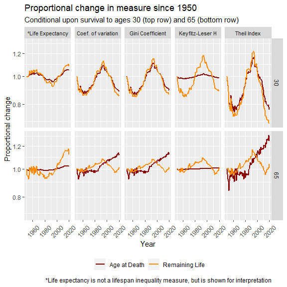

```r
library(ggplot2)
library(scales)
# comparison conditional upon survival to ages 30 and 65

ggplot(data=Ineq_change,
          aes(x=Year, y=Prop_change, colour=Dist_type)) +
     geom_line(size=1) +
     facet_grid(Age ~ Family) +
    ylab("Proportional change") +
    scale_colour_manual(values=c("darkred", "darkorange")) +
    labs(title = "Proportional change in measure since 1950",
        subtitle = "Conditional upon survival to ages 30 (top row) and 65 (bottom row)",
        caption = "*Life expectancy is not a lifespan inequality measure, but is shown for interpretation") +
    coord_trans(y="log2") + #for our friend Ilya
    theme(strip.text.x = element_text(size=8),
          legend.position="bottom",
          legend.title=element_blank(),
          axis.text.x  = element_text(angle=45, vjust=0.5, size=10))
```

So as this example makes clear, what goes in the denominator for conditional measures of lifespan variation can make an enormous difference in interpreting the variability. This is especially important at older ages, when relative differences over time (or between populations) in remaining life will be much larger than relative differences in ages at death.

## References

Allison, Paul D. 1978. “Measures of Inequality.” *American Sociological Review*, 865–80.

Barbieri, Magali, John R Wilmoth, Vladimir M Shkolnikov, Dana Glei, Domantas Jasilionis, Dmitri Jdanov, Carl Boe, Timothy Riffe, Pavel Grigoriev, and Celeste Winant. 2015. “Data Resource Profile: The Human Mortality Database (HMD).” *International Journal of Epidemiology* 44 (5): 1549–56.

Baudisch, Annette. 2011. “The Pace and Shape of Ageing.” *Methods in Ecology and Evolution* 2 (4): 375–82.

Bramajo, Octavio, Iñaki Permanyer, and Amand Blanes. 2022. “Regional Inequalities in Life Expectancy and Lifespan Variation by Educational Attainment in Spain, 2014–2018.” *Population, Space and Place*, e28.

Camarda, Carlo G. 2012. “MortalitySmooth: An R Package for Smoothing Poisson Counts with P-Splines.” *Journal of Statistical Software* 50 (1): 1–24. http://www.jstatsoft.org/v50/i01/.

Colchero, Fernando, Roland Rau, Owen R Jones, Julia A Barthold, Dalia A Conde, Adam Lenart, Laszlo Nemeth, et al. 2016. “The Emergence of Longevous Populations.” *Proceedings of the National Academy of Sciences* 113 (48): E7681–90.

Eakin, Tim, and Matthew Witten. 1995. “How Square Is the Survival Curve of a Given Species?” *Experimental Gerontology* 30 (1): 33–64.

Goldman, Noreen, and Graham Lord. 1986. “A New Look at Entropy and the Life Table.” *Demography* 23 (2): 275–82.

Hakkert, Ralph. 1987. “Life Table Transformations and Inequality Measures: Some Noteworthy Formal Relationships.” *Demography*, 615–22.

HMD. 2023. *Human Mortality Database*. https://mortality.org/.

Németh, László. 2017. “Life Expectancy Versus Lifespan Inequality: A Smudge or a Clear Relationship?” *PLoS One* 12 (9): e0185702.

Pascariu, Marius D. 2019. *MortalityLaws: Parametric Mortality Models, Life Tables and HMD*. https://CRAN.R-project.org/package=MortalityLaws.

Permanyer, Iñaki, and Nathalie Scholl. 2019. “Global Trends in Lifespan Inequality: 1950-2015.” *PloS One* 14 (5): e0215742.

Riffe, Tim, Carl Boe, and Jason Hilton. 2023. *HMDHFDplus: Read Human Mortality Database and Human Fertility*. https://CRAN.R-project.org/package=HMDHFDplus.

Seaman, Rosie, Andreas Höhn, Rune Lindahl-Jacobsen, Pekka Martikainen, Alyson van Raalte, and Kaare Christensen. 2020. “Rethinking Morbidity Compression.” *European Journal of Epidemiology* 35 (5): 381–88.

Shkolnikov, Vladimir M, and Evgeny M Andreev. 2010. “Spreadsheet for Calculation of Life-Table Dispersion Measures.” *Max Planck Institute for Demographic Research (MPIDR Technical Report TR–2012–002)*. https://doi.org/10.4054/MPIDR-TR-2010-001.

Shkolnikov, Vladimir M, Evgueni M Andreev, and Alexander Z Begun. 2003. “Gini Coefficient as a Life Table Function: Computation from Discrete Data, Decomposition of Differences and Empirical Examples.” *Demographic Research* 8: 305–58.

van Raalte, Alyson A, and Hal Caswell. 2013. “Perturbation Analysis of Indices of Lifespan Variability.” *Demography* 50 (5): 1615–40.

van Raalte, Alyson A, Anton E Kunst, Olle Lundberg, Mall Leinsalu, Pekka Martikainen, Barbara Artnik, Patrick Deboosere, Irina Stirbu, Bogdan Wojtyniak, and Johan P Mackenbach. 2012. “The Contribution of Educational Inequalities to Lifespan Variation.” *Population Health Metrics* 10 (1): 1–10.

Vaupel, James W. 1986. “How Change in Age-Specific Mortality Affects Life Expectancy.” *Population Studies* 40 (1): 147–57.

Wilmoth, John R, and Shiro Horiuchi. 1999. “Rectangularization Revisited: Variability of Age at Death Within Human Populations.” *Demography* 36 (4): 475–95.

Wrycza, Tomasz F, Trifon I Missov, and Annette Baudisch. 2015. “Quantifying the Shape of Aging.” *PloS One* 10 (3): e0119163.